# US Used Car Price Prediction: Machine Learning Analysis

Fredrick George Mbuya

2023-03-01

# 1 Libraries used

```r
library(plyr)
library(validate)
library(dlookr)
library(dplR)
```

```r
library(pacman)
library(ggplot2)
library(modeest)
library(moments)
library(dplyr)
library(AICcmodavg)
library(clustMixType)
library(cluster)
library(gridExtra)
library(lattice)
library(caret)
library(rpart.plot)
library(mlbench)
```

# 2 Loading data into R

```r
used_car <- read.csv("true_car_listings.csv", na.strings = c("NA",""))
```

# 3 Data quality inspections

## 3.1 Defining the valiadation Rules

1. The car’s price (Price), and the year it was purchased (Year) should all be non-negative and numerical.
2. The number of kilometers driven by the car (Mileage) should be greater than zero and numerical.
3. The city and state where the car was sold should all be Character.
4. A car’s unique number (Vin), manufacturer (Make), and model (name) should all be characters.
5. Examine for the presence of missing values.
6. Examine for the presence of duplicated records.
7. The length of the year in which the car was purchased (Year) should be equal to four.
8. The length of each state should be equal to two.
9. The length of the city, vin, and Make should be greater than or equal to two.
10. The latest year in which the car was purchased (Year) should be 2023. No Minimum year just because america there is no that regulation

## 3.2 Developing validator function

```r
#Allow variables to be accessed without having to type the data frame's name.
attach(used_car)

#Creating Validator
used_car_rules <- validator(Non_negPrice = Price>=0,
                            Non_negYear = Year>=0,
                            Non_negMiliage = Mileage>0,
                            YearLength = field_length(Year, n=4),
                            StateLength = field_length(State, n=2),
                            CityLength = nchar(City)>=2,
                            VinLength = nchar(Vin)>=2,
                            MakeLength = nchar(Make)>=2,
                            MaxYear = Year<=2023,
                            DataUnique = is_unique(used_car),
                            MissingValue = !is.na(used_car),
                            StringVin = is.character(Vin),
                            StringMake = is.character(Make),
                            StringModel = is.character(Model),
                            NumberPrice = is.numeric(Price),
                            NumberYear = is.numeric(Year),
                            NumberMleage = is.numeric(Mileage))


# Apply the rules to the data and save the results in a variable called out.
out <- confront(used_car, used_car_rules)

# The easiest way to check the results is with summary()
summary(out)
```

```
##              name   items  passes  fails nNA error warning
## 1    Non_negPrice  852122  852122      0   0 FALSE   FALSE
## 2     Non_negYear  852122  852122      0   0 FALSE   FALSE
## 3  Non_negMiliage  852122  852122      0   0 FALSE   FALSE
## 4      YearLength  852122  852122      0   0 FALSE   FALSE
## 5     StateLength  852122       0 852122   0 FALSE   FALSE
## 6      CityLength  852122  852122      0   0 FALSE   FALSE
## 7       VinLength  852122  852122      0   0 FALSE   FALSE
## 8      MakeLength  852122  852122      0   0 FALSE   FALSE
## 9         MaxYear  852122  852122      0   0 FALSE   FALSE
## 10     DataUnique  852122  852062     60   0 FALSE   FALSE
## 11   MissingValue 6816976 6816976      0   0 FALSE   FALSE
## 12      StringVin       1       1      0   0 FALSE   FALSE
## 13     StringMake       1       1      0   0 FALSE   FALSE
## 14    StringModel       1       1      0   0 FALSE   FALSE
```

[output cut: 21 more lines]

The output above shows that,  
. The car’s price (Price) and year of purchase (Year) are all non-negative and numerical values.  
. The number of kilometres driven (Mileage) by the car is greater than zero, proving that all sold cars are used.  
. The city and state where the car was sold, The unique number (Vin), manufacturer (Make), and model (name) of a car are all Characters.  
.There are no missing values, .The Year variable has a length of 4, and all years were less than 2023, the current year,  
.The lengths of the City, Vin, and MAKE variables are all greater than or equal to two. .There are 30 duplicate records (60 divided by two).  
.State lengths are not all equal to two, implying that there might be space before, after, or between data.

We can use the violating() to select records that violate one or more rules, but we will use only first ten rules because the remaining rules can not have record-wise interpretation.

```r
violating(used_car,out[1:10])
```

```
##        Price Year Mileage                 City State               Vin  Make
## 1       8995 2014   35725              El Paso    TX 19VDE2E53EE000083 Acura
## 2      10888 2013   19606     Long Island City    NY 19VDE1F52DE012636 Acura
## 3       8995 2013   48851              El Paso    TX 19VDE2E52DE000025 Acura
## 4      10999 2014   39922              Windsor    CO 19VDE1F71EE003817 Acura
## 5      14799 2016   22142               Lindon    UT 19UDE2F32GA001284 Acura
## 6       7989 2012  105246                Miami    FL JH4CU2F83CC019895 Acura
## 7      14490 2014   34032            Greatneck    NY JH4CU2F84EC002686 Acura
## 8      13995 2013   32384          West Jordan    UT JH4CU2F64DC006203 Acura
## 9      10495 2013   57596            Waterbury    CT 19VDE2E50DE000234 Acura
## 10      9995 2013   63887              El Paso    TX 19VDE1F50DE010450 Acura
## 11     12921 2012   58550                Boise    ID JH4CU2F44CC003220 Acura
## 12     12000 2013   40527     Long Island City    NY 19VDE1F38DE020867 Acura
## 13      7750 2009   91980          San Antonio    TX JH4CU26639C015787 Acura
## 14     17628 2015   13797                Fargo    ND 19VDE1F38FE001240 Acura
```

[output cut: 24986 more lines]

# 4 Data Cleaning

## 4.1 removing any gap that exists before, after, or between

. I will not deal with the State column only for the great benefits of other variables and reducing the size of the data. To remove leading, trailing, and all unnecessary white spaces from the entire data set, use gsub (). This will return a matrix, but we will convert it back to a data frame using as.data.frame ()

NB: *\s+, which is a regular expression that matches one or more whitespace characters, such as spaces, tabs, and newlines.*

```r
#Creating the function
space_remover <- function(x){
  gsub('\\s+', '', x)
}

#Applying the function to every column
used_car <- apply(used_car, 2, space_remover)

#Convert the Matrix output back to data frame
used_car <- as.data.frame(used_car)
```

## 4.2 Omitting unnecessary punctuation.

```r
#Exist between, before, and after a data point for City, State, Vin, and Make Variables.
used_car$City <- gsub("[[:punct:]]", "", used_car$City)
used_car$State <- gsub("[[:punct:]]", "", used_car$State)
used_car$Vin <- gsub("[[:punct:]]", "", used_car$Vin)
used_car$Make <- gsub("[[:punct:]]", "", used_car$Make)

#On a Model Variable, exist before or after a data point.
used_car$Model <- gsub("^[[:punct:]]+|[[:punct:]]+$", "", used_car$Model)
```

## 4.3 Changing the character variables to factor for Memory efficiency and Consistency

.Using as.factor()

```r
# Convert the 'City', 'State', 'Vin', 'Make', and 'Model' variables to factor data type.
used_car$City <- as.factor(used_car$City)
used_car$State <- as.factor(used_car$State)
used_car$Vin <- as.factor(used_car$Vin)
used_car$Make <- as.factor(used_car$Make)
used_car$Model <- as.factor(used_car$Model)

# Check the structure of the 'used_car' data frame.
str(used_car)
```

```
## 'data.frame':    852122 obs. of  8 variables:
##  $ Price  : chr  "8995" "10888" "8995" "10999" ...
##  $ Year   : chr  "2014" "2013" "2013" "2014" ...
##  $ Mileage: chr  "35725" "19606" "48851" "39922" ...
##  $ City   : Factor w/ 2538 levels "Abbeville","Aberdeen",..: 668 1258 668 2483 1229 1391 887 2426 2377 668 ...
##  $ State  : Factor w/ 59 levels "AK","AL","AR",..: 51 41 51 8 52 13 41 52 9 51 ...
##  $ Vin    : Factor w/ 852075 levels "04WT3N56GG0646582",..: 3973 3708 3971 3825 43 649120 649127 648931 3967 3685 ...
##  $ Make   : Factor w/ 58 levels "Acura","Alfa",..: 1 1 1 1 1 1 1 1 1 1 ...
##  $ Model  : Factor w/ 2706 levels "1","124","1500",..: 1209 1208 1209 1208 1211 2368 2371 2367 1209 1208 ...
```

Looking at the structure of the dataset we also notice that our numerical data is in a character format. This needs to be changed.

```r
# Convert 'Price', 'Mileage', 'Year' columns to integer data type for better data handling
used_car$Price <- as.integer(used_car$Price)
used_car$Mileage <- as.integer(used_car$Mileage)
used_car$Price <- as.integer(used_car$Price)
used_car$Year <- as.integer(used_car$Year)

# Check the data structure of 'used_car' dataframe
str(used_car)
```

```
## 'data.frame':    852122 obs. of  8 variables:
##  $ Price  : int  8995 10888 8995 10999 14799 7989 14490 13995 10495 9995 ...
##  $ Year   : int  2014 2013 2013 2014 2016 2012 2014 2013 2013 2013 ...
##  $ Mileage: int  35725 19606 48851 39922 22142 105246 34032 32384 57596 63887 ...
##  $ City   : Factor w/ 2538 levels "Abbeville","Aberdeen",..: 668 1258 668 2483 1229 1391 887 2426 2377 668 ...
##  $ State  : Factor w/ 59 levels "AK","AL","AR",..: 51 41 51 8 52 13 41 52 9 51 ...
##  $ Vin    : Factor w/ 852075 levels "04WT3N56GG0646582",..: 3973 3708 3971 3825 43 649120 649127 648931 3967 3685 ...
##  $ Make   : Factor w/ 58 levels "Acura","Alfa",..: 1 1 1 1 1 1 1 1 1 1 ...
##  $ Model  : Factor w/ 2706 levels "1","124","1500",..: 1209 1208 1209 1208 1211 2368 2371 2367 1209 1208 ...
```

## 4.4 Changing to lower case

The variables “City,” “State,” “Make,” and “Model” in the dataset are converted to lower case before being converted back to factors. This is done to ensure that the spelling and formatting of these variables are consistent across the whole dataset. Each factor’s levels are then examined to ensure that they match the expected values. When working with categorical variables in the dataset, this approach helps to prevent errors and inconsistencies.

```r
# Convert all values in the City, State, Make, and Model variables to lowercase
used_car$City <- tolower(used_car$City)
used_car$State <- tolower(used_car$State)
used_car$Make <- tolower(used_car$Make)
used_car$Model <- tolower(used_car$Model)

# Convert the City, State, Make, and Model variable back to factors
used_car$City <- as.factor(used_car$City)
used_car$State <- as.factor(used_car$State)
used_car$Make <- as.factor(used_car$Make)
used_car$Model <- as.factor(used_car$Model)

# Display the levels of the City, State, Make, and Model variables
levels(used_car$City)
```

```
##    [1] "abbeville"            "aberdeen"             "abilene"
##    [4] "abington"             "acton"                "acworth"
##    [7] "ada"                  "adamsburg"            "addison"
##   [10] "adel"                 "adrian"               "aiea"
##   [13] "aiken"                "akron"                "alachua"
##   [16] "alameda"              "alamogordo"           "albany"
##   [19] "albemarle"            "albermarle"           "albertlea"
##   [22] "albertville"          "albion"               "albuqueque"
##   [25] "albuquerque"          "alcoa"                "alexandercity"
##   [28] "alexandria"           "algonquin"            "alhambra"
##   [31] "allentown"            "alliance"             "alpharetta"
##   [34] "alsip"                "alto"                 "alton"
##   [37] "altus"                "alvin"                "amarillo"
##   [40] "amelia"               "americanfork"         "americus"
##   [43] "amesbury"             "amherst"              "amityville"
```

[output cut: 782 more lines]

```r
levels(used_car$State)
```

```
##  [1] "ak" "al" "ar" "az" "ca" "co" "ct" "dc" "de" "fl" "ga" "hi" "ia" "id" "il"
## [16] "in" "ks" "ky" "la" "ma" "md" "me" "mi" "mn" "mo" "ms" "mt" "nc" "nd" "ne"
## [31] "nh" "nj" "nm" "nv" "ny" "oh" "ok" "or" "pa" "ri" "sc" "sd" "tn" "tx" "ut"
## [46] "va" "vt" "wa" "wi" "wv" "wy"
```

```r
levels(used_car$Make)
```

```
##  [1] "acura"        "alfa"         "am"           "aston"        "audi"
##  [6] "bentley"      "bmw"          "buick"        "cadillac"     "chevrolet"
## [11] "chrysler"     "dodge"        "ferrari"      "fiat"         "fisker"
## [16] "ford"         "freightliner" "genesis"      "geo"          "gmc"
## [21] "honda"        "hummer"       "hyundai"      "infiniti"     "isuzu"
## [26] "jaguar"       "jeep"         "kia"          "lamborghini"  "land"
## [31] "lexus"        "lincoln"      "lotus"        "maserati"     "maybach"
## [36] "mazda"        "mclaren"      "mercedesbenz" "mercury"      "mini"
## [41] "mitsubishi"   "nissan"       "oldsmobile"   "plymouth"     "pontiac"
## [46] "porsche"      "ram"          "rollsroyce"   "saab"         "saturn"
## [51] "scion"        "smart"        "subaru"       "suzuki"       "tesla"
## [56] "toyota"       "volkswagen"   "volvo"
```

```r
levels(used_car$Model)
```

```
##    [1] "1"                                  "124"
##    [3] "1500"                               "15002wd"
##    [5] "15004wd"                            "1500big"
##    [7] "1500express"                        "1500hfe"
##    [9] "1500laramie"                        "1500limited"
##   [11] "1500lone"                           "1500longhorn"
##   [13] "1500new"                            "1500night"
##   [15] "1500outdoorsman"                    "1500r/t"
##   [17] "1500ram"                            "1500rebel"
##   [19] "1500slt"                            "1500sport"
##   [21] "1500ssv"                            "1500tradesman"
##   [23] "2"                                  "200"
##   [25] "2002dr"                             "2004dr"
##   [27] "200c"                               "200convertible"
##   [29] "200limited"                         "200lx"
```

[output cut: 1320 more lines]

```r
# Display the structure of the 'used_car' data frame
str(used_car)
```

```
## 'data.frame':    852122 obs. of  8 variables:
##  $ Price  : int  8995 10888 8995 10999 14799 7989 14490 13995 10495 9995 ...
##  $ Year   : int  2014 2013 2013 2014 2016 2012 2014 2013 2013 2013 ...
##  $ Mileage: int  35725 19606 48851 39922 22142 105246 34032 32384 57596 63887 ...
##  $ City   : Factor w/ 2389 levels "abbeville","aberdeen",..: 627 1187 627 2335 1158 1313 836 2281 2234 627 ...
##  $ State  : Factor w/ 51 levels "ak","al","ar",..: 44 35 44 6 45 10 35 45 7 44 ...
##  $ Vin    : Factor w/ 852075 levels "04WT3N56GG0646582",..: 3973 3708 3971 3825 43 649120 649127 648931 3967 3685 ...
##  $ Make   : Factor w/ 58 levels "acura","alfa",..: 1 1 1 1 1 1 1 1 1 1 ...
##  $ Model  : Factor w/ 2669 levels "1","124","1500",..: 1196 1195 1196 1195 1198 2335 2338 2334 1196 1195 ...
```

## 4.5 Removing duplicated records

.To eliminate duplicate records, we use unique().

```r
used_car <-unique(used_car)
```

# 5 Outliers handling

We can see from the results below that there are outliers in all of the numerical data. We can see the impact on the data by comparing the ones with and without outliers.

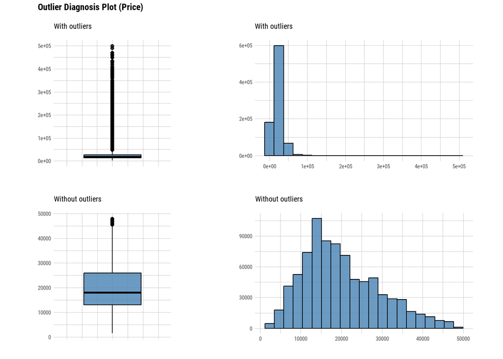

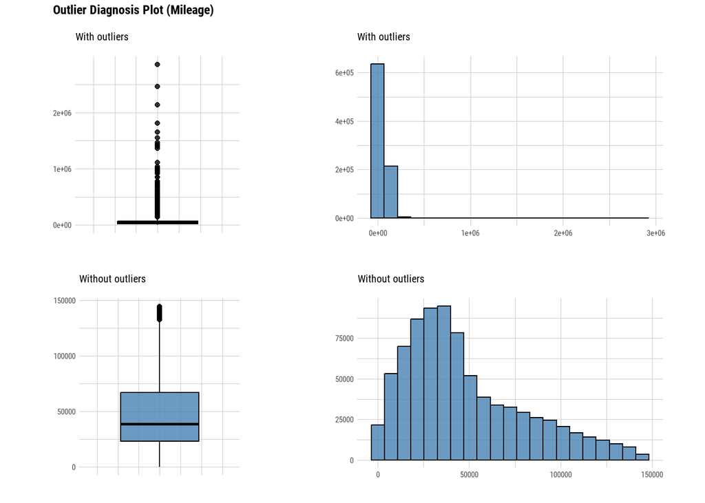

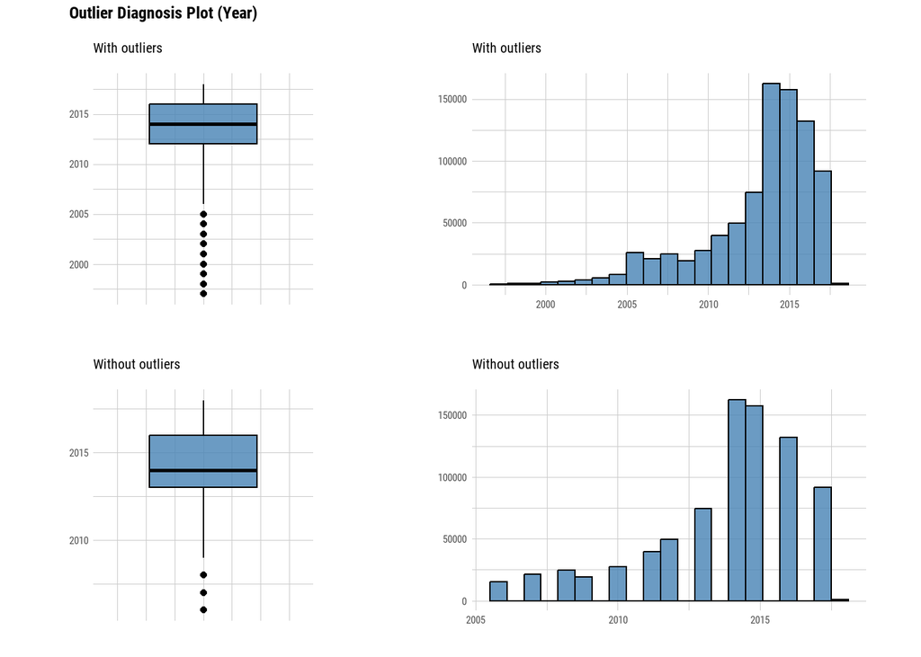

```r
# See if there are any odd values
plot_outlier(used_car, Price, Mileage, Year)
```

Before making any decisions, we must first determine whether these outliers are true incorrect values or contain information. To find out, we must delve deeper into the data. We can see the values for these outliers by using the boxplot.stats() functions.

```r
# Identify nature of outliers in Price, Mileage, and Year variables
boxplot.stats(used_car$Price)$out
```

```
##     [1]  47995  47995  47988  47990  48500  48019  47995  47995  47995  47999
##    [11]  48400  48000  49755  48575  48000  48980  49000  48999  49711  48900
##    [21]  48999  48990  51435  51435  49900  49939  49986  51642  50900  47995
##    [31]  52000  52000  52000  52000  49820  52000  52000  52000  48995  51771
##    [41]  51435  51435  51435  51435  51435  51435  51435  51492  51969  51435
##    [51]  51000  51300  51687  51692  52995  52000  52000  52498  52597  52487
##    [61]  52900  51993  53177  53993  54515  53993  51995  51998  57340  47998
##    [71]  47988  50771  51771  51771  48000  49981  49981  49991  50771  49900
##    [81]  49988  51771  51771  51771  51771  57771  50771  50771  51771  51771
##    [91]  51771  84990  89000  99999 162500 165888 165997 169929 169998 175600
##   [101] 173998 164837 165399 164995 179360 169777 185995 188300 178999 189000
##   [111] 179000 179000 194000 184000  47999  50989  55495  55994  56999  56500
##   [121]  56999  57950  56950  59880  59995  61443  63522  63995  69990  74977
##   [131]  76899  77420  78987  81000  80950  81900  88245  48900  54990  49999
##   [141]  56400  54995  67000  67995  61998  59980  59995  64000  65999  69995
```

[output cut: 2788 more lines]

```r
boxplot.stats(used_car$Mileage)$out
```

```
##     [1]  159601  158997  149122  146017  154566  149924  150057  170470  163012
##    [10]  150383  166671  160619  159687  176743  147000  157237  149872  147858
##    [19]  158462  163458  167554  185179  189350  172148  171347  154260  147798
##    [28]  145270  165476  158881  158120  163655  163763  171935  174002  150500
##    [37]  166290  156705  182179  165033  155137  169524  170902  174773  171895
##    [46]  185918  187132  191380  149086  175338  159468  192177  154656  210939
##    [55]  189327  147617  161479  174600  148095  167948  167321  190852  147285
##    [64]  144801  170905  198679  164694  146400  204157  155023  167927  167362
##    [73]  212575  150949  146000  194122  179938  157709  147035  144898  148164
##    [82]  148486  146189  145571  155658  154966  152129  144995  166116  151765
##    [91]  157631  163505  171054  166127  153322  147916  148103  149089  149562
##   [100]  147578  159253  166693  155957  153780  146023  146052  145254  176368
##   [109]  157614  159032  160276  153089  166882  149008  145932  152176  160085
##   [118]  164595  145672  159746  148145  153883  152911  146845  159148  166527
##   [127]  149446  149460  163822  148600  150568  179050  172717  162652  148589
```

[output cut: 3496 more lines]

```r
boxplot.stats(used_car$Year)$out
```

```
##     [1] 2004 2005 2005 2005 2005 2004 2005 2005 2004 2005 2005 2005 2005 2004
##    [15] 2005 2004 2005 2005 2005 2004 2004 2004 2005 2005 2003 2005 2004 2004
##    [29] 2004 2005 2004 2004 2005 2004 2005 2004 2003 2003 2005 2004 2003 2004
##    [43] 2004 2004 2002 2005 2005 2005 2004 2005 2003 2004 2005 2004 2005 2004
##    [57] 2005 2005 2004 2005 2005 2005 2005 2005 2002 2004 2005 2004 2002 2004
##    [71] 2004 2005 2004 2005 2004 2003 2004 2003 2004 2005 2005 2005 2002 2005
##    [85] 2002 2005 1999 2005 2005 2004 2004 2005 2001 2005 2005 2003 2000 2005
##    [99] 2005 2005 2004 2005 2004 2004 2005 2004 2005 2005 2003 2000 2004 2004
##   [113] 2005 2005 2001 2003 2005 2004 2004 2005 2004 2004 2004 2004 2005 2005
##   [127] 2004 2000 2002 2004 2000 2005 2003 2005 2002 2001 2005 2005 2002 2005
##   [141] 2004 2005 2003 2004 2004 2004 2005 2005 2005 1999 2004 2004 2002 2002
##   [155] 1998 2004 2005 1999 2004 2003 2005 2004 2003 2003 2003 2001 2002 2005
##   [169] 2004 2004 2003 2004 2005 2004 2005 2002 2005 2004 2003 2004 1999 2005
##   [183] 2004 2004 2005 2004 2005 2004 2005 1999 2004 2005 2004 2000 2003 2004
##   [197] 2005 2001 2000 2004 2000 2003 2002 2002 2004 2000 2003 2004 2005 2001
```

[output cut: 2536 more lines]

```r
# Summary statistics for Price, Year, and Mileage variables
summary(used_car$Price)
```

```
##    Min. 1st Qu.  Median    Mean 3rd Qu.    Max.
##    1500   13000   18500   21464   26995  499500
```

```r
summary(used_car$Year)
```

```
##    Min. 1st Qu.  Median    Mean 3rd Qu.    Max.
##    1997    2012    2014    2013    2016    2018
```

```r
summary(used_car$Mileage)
```

```
##    Min. 1st Qu.  Median    Mean 3rd Qu.    Max.
##       5   23836   40256   52508   72187 2856196
```

According to the results, the data set contains a significant number of outliers, indicating that there are several used cars with prices significantly higher than the rest of the cars in the sample. The boxplot range also indicates that the data distribution is skewed to the right, indicating that there are more cars with lower prices than with higher prices. So we will analyze more about this in explonatory data analysis to make more informed decision

# 6 Data Sampling

A random sample of 3% of the observations from the data has been picked and stored as a current data labelled **used_car_reduced** using R’s sample() function. The goal is to reduce the dataset for exploratory data analysis (EDA) while retaining the general structure and characteristics of the original dataset. When handling large sets of data, this is most often performed in order to render the data more manageable and reduce computational complexity.

```r
#Counting the number of observations and storing them in n_rows
n_rows <- nrow(used_car)

#Sampling formula
used_car_idx <- sample(n_rows, n_rows*0.03)

#Take 3% of the entire data set at random and save the results to the variable used_car_reduced.
used_car_reduced <- used_car[used_car_idx,]

#Keeping the output
write.csv(used_car_reduced, "used_car_reduced.csv")
```

# 7 Explonatory Data Analysis

## 7.1 Removing Columns Vin column

```r
#Vin as a unique identifier, we do not work with it in the next steps
used_car_reduced <- used_car_reduced[, !(names(used_car_reduced) %in% c("Vin"))]
```

## 7.2 Summary Statistics

```r
summary(used_car_reduced)
```

```
##      Price             Year         Mileage                 City
##  Min.   :  1500   Min.   :1997   Min.   :     5   houston     :  341
##  1st Qu.: 13198   1st Qu.:2012   1st Qu.: 24006   sanantonio  :  259
##  Median : 18500   Median :2014   Median : 40455   louisville  :  187
##  Mean   : 21452   Mean   :2013   Mean   : 52172   jacksonville:  186
##  3rd Qu.: 26990   3rd Qu.:2016   3rd Qu.: 71554   raleigh     :  181
##  Max.   :403514   Max.   :2018   Max.   :383257   miami       :  177
##                                                   (Other)     :24231
##      State              Make             Model
##  tx     : 2893   ford     : 3353   silverado:  743
##  ca     : 2387   chevrolet: 3080   grand    :  561
##  fl     : 2277   toyota   : 2347   f-1504wd :  401
##  nc     : 1144   nissan   : 1998   accord   :  399
##  ga     : 1123   honda    : 1453   3        :  362
##  il     : 1120   jeep     : 1196   civic    :  353
##  (Other):14618   (Other)  :12135   (Other)  :22743
```

```r
# Using the modeest library we can find mode using mfv function
yearMode <- mfv(used_car_reduced$Year)
priceMode <- mfv(used_car_reduced$Price)
milgMode <- mfv(used_car_reduced$Mileage)

# Printing out mode values
cat("Mode:\n", "Year: ", yearMode, "\nPrice: ", priceMode, "\nMileage: ", milgMode)
```

```
## Mode:
##  Year:  2014
## Price:  16995
## Mileage:  10
```

.Furthermore, the median price is less than the mean price, indicating that there are a few extremely expensive used cars and that the price distribution is skewed to the right.

.Texas, California, and Florida have the most used cars for sale of any state, with the most in Houston, San Antonio, and Louisville.

## 7.3 Confirming the structure

```r
str(used_car_reduced)
```

```
## 'data.frame':    25562 obs. of  7 variables:
##  $ Price  : int  14898 9995 29995 35300 39489 26685 9484 28294 6994 23955 ...
##  $ Year   : int  2014 2007 2015 2014 2015 2015 2015 2015 2005 2013 ...
##  $ Mileage: int  38488 114000 59225 82452 40013 32035 22597 49413 59882 56445 ...
##  $ City   : Factor w/ 2389 levels "abbeville","aberdeen",..: 242 1866 355 664 1359 75 1919 460 1308 128 ...
##  $ State  : Factor w/ 51 levels "ak","al","ar",..: 35 5 28 36 5 22 10 43 4 21 ...
##  $ Make   : Factor w/ 58 levels "acura","alfa",..: 56 42 7 56 20 20 16 16 21 42 ...
##  $ Model  : Factor w/ 2669 levels "1","124","1500",..: 405 240 2498 2055 2647 210 959 887 222 246 ...
```

.Based on the findings, it is confirmed that the data set contains 25562 observations (rows) and 7 variables, with the variables “Price,” “Year,” and “Mileage” being integers and the variables “City,” “State,” “Make,” and “Model” being factors with various levels.

## 7.4 Exploaring numerical variables

### 7.4.1 Statistical dispersion

```r
# Here we can see what the standard deviation of the numerical data are
priceSD <- sd(used_car_reduced$Price)
milgSD <- sd(used_car_reduced$Mileage)

# Here we are find the variance of our numerical data using the var() method
priceVar <- var(used_car_reduced$Price)
milgVar <- var(used_car_reduced$Mileage)

# Here we are find the IQR of our numerical data using the IQR() method
priceIQR <- IQR(used_car_reduced$Price)
milgIQR <- IQR(used_car_reduced$Mileage)

# Here we are find the Median Absolute Deviance (MAD) of our numerical data using mad()
priceMad <- mad(used_car_reduced$Price)
milgMad <- mad(used_car_reduced$Mileage)

# Printing out all of our statistical dispersion variables
cat("standard deviation:\n", "price = ", priceSD, "\n mileage = ", milgSD,
    "\n\n--------------------------------------------------------------------\n",
    "\nVariance:\n", "price = ", priceVar, "\n mileage = ", milgVar,
    "\n\n--------------------------------------------------------------------\n",
    "\nInter-Quartile Range:\n", "price = ", priceIQR, "\n mileage = ", milgIQR,
    "\n\n--------------------------------------------------------------------\n",
    "\nMedian Absolute Deviance:\n", "price = ", priceMad, "\n mileage = ", milgMad)
```

```
## standard deviation:
##  price =  13819.19
##  mileage =  40361.63
##
## --------------------------------------------------------------------
##
## Variance:
##  price =  190970000
##  mileage =  1629060957
##
## --------------------------------------------------------------------
##
## Inter-Quartile Range:
##  price =  13792.25
##  mileage =  47547.75
##
## --------------------------------------------------------------------
##
## Median Absolute Deviance:
##  price =  9622.074
##  mileage =  30620.14
```

### 7.4.2 Distribution shape

```r
#calculate skewness
priceSkew <- skewness(used_car_reduced$Price)
milgSkew <- skewness(used_car_reduced$Mileage)

#calculate kurtosis
priceKur <- kurtosis(used_car_reduced$Price)
milgKur <- kurtosis(used_car_reduced$Mileage)

# Printing out Skewness and Kurtosis
cat("skewness:\n", "price = ", priceSkew, "\n mileage = ", milgSkew,
    "\n\n--------------------------------------------------------------------\n",
    "\nKurtosis:\n", "price = ", priceKur, "\n mileage = ", milgKur)
```

```
## skewness:
##  price =  6.106541
##  mileage =  1.468485
##
## --------------------------------------------------------------------
##
## Kurtosis:
##  price =  109.64
##  mileage =  5.805398
```

.The skewness and kurtosis values show that both the price and mileage distributions in the dataset are right-skewed, with a higher concentration of lower values, and have heavier tails than a normal distribution. The skewness and kurtosis of the price distribution are more noticeable than those of the mileage distribution. This observation aligns with what can be seen from the summary statistics.

### 7.4.3 QQ plots; confirming distribution shape

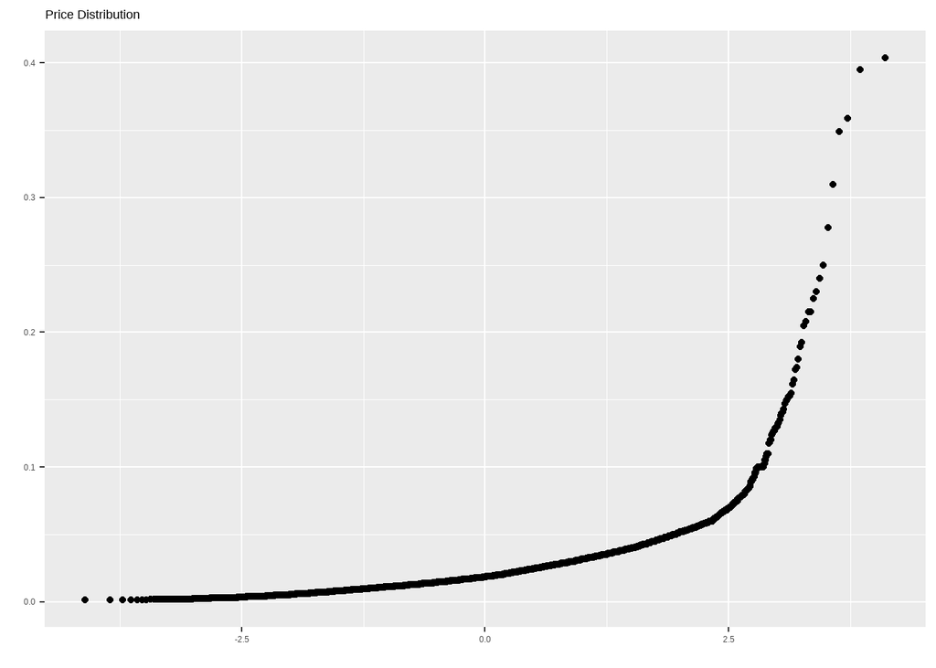

```r
# Price
qplot(sample = Price, data = used_car_reduced) +
  ggtitle("Price Distribution") +
  scale_y_continuous(labels = scales::label_number(scale = 1e-6))
```

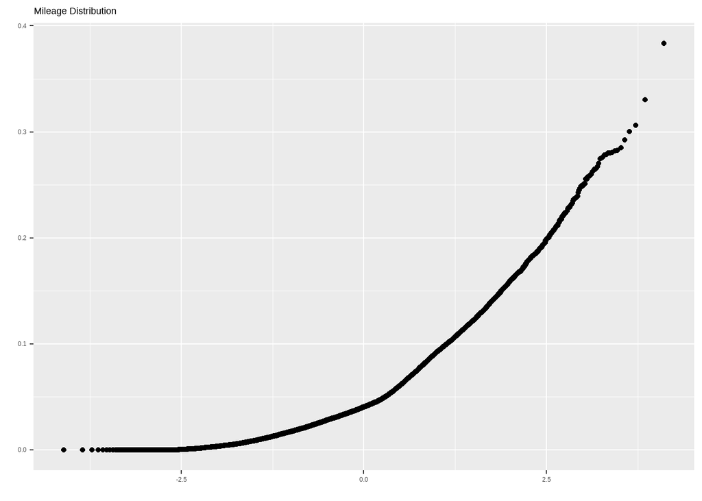

```r
# Mileage
qplot(sample = Mileage, data = used_car_reduced) +
  ggtitle("Mileage Distribution") +
  scale_y_continuous(labels = scales::label_number(scale = 1e-6))
```

.The Q-Q plot analysis agrees with the earlier observation that neither Price nor Mileage data follows a normal distribution because the lines are not straight. This could mean that common summary statistics like the mean and standard deviation might not give a full or accurate picture of the data. Instead, median or interquartile range might be a better choice.

### 7.4.4 Histogram

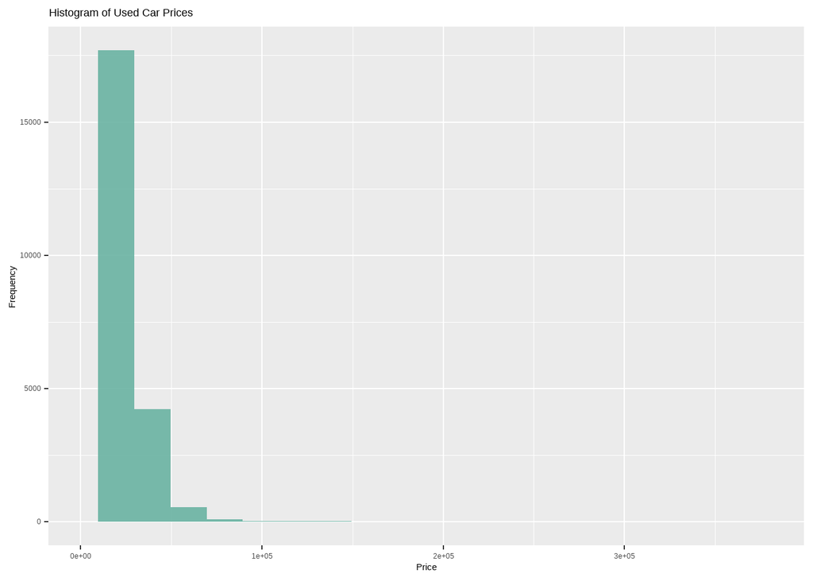

```r
#Histogram of Used Car Prices
ggplot(used_car_reduced, aes(x=Price)) +
  geom_histogram( bins = 20, fill="#69b3a2", alpha=0.9) +
  xlim(1500,379900)+
  labs(x = "Price", y = "Frequency",
       title = "Histogram of Used Car Prices")
```

.The histogram’s right-skewed distribution confirms the conclusion drawn from summary statistics that most prices fall in the lower range and a few prices are extremely high. The right side of the distribution has a lengthy tail, suggesting the existence of outliers.

```r
#Histogram of Used Car Year
png(filename = "Histogram_Year.png")
ggplot(used_car_reduced, aes(x=Year)) +
  geom_histogram(bins = 20, fill="#69b3a2", alpha=0.9) +
  labs(x = "Year", y = "Frequency",
       title = "Histogram of Used Car Year")
```

[output not shown]

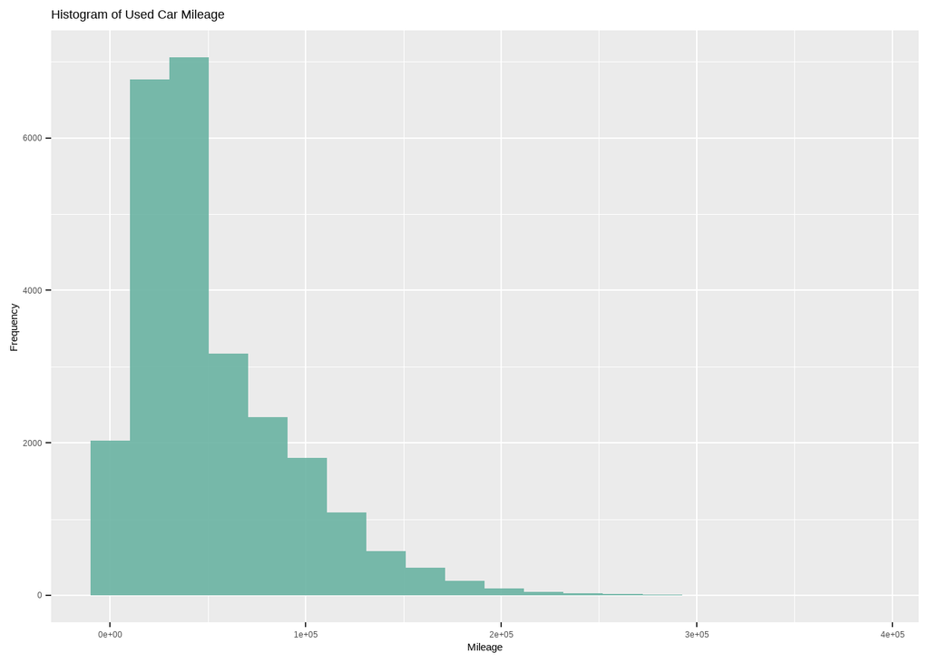

```r
#Histogram of Used Car Mileage
ggplot(used_car_reduced, aes(x=Mileage)) +
  geom_histogram(bins = 20, fill="#69b3a2", alpha=0.9) +
  labs(x = "Mileage", y = "Frequency",
       title = "Histogram of Used Car Mileage")
```

.The histogram appears to be right-skewed, indicating that the majority of used cars have lower mileage (below 100,000Kms).

### 7.4.5 Correlation analysis

#### 7.4.5.1 Using cor()

```r
#Round it to two decimal places
round(cor(used_car_reduced[1:3]),2)
```

```
##         Price  Year Mileage
## Price    1.00  0.38   -0.42
## Year     0.38  1.00   -0.78
## Mileage -0.42 -0.78    1.00
```

#### 7.4.5.2 Using Scatterplots

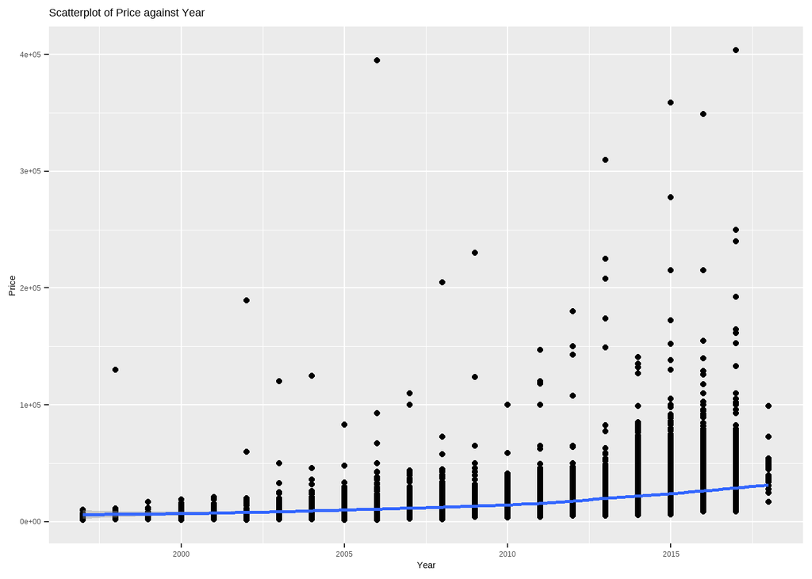

```r
# Price against Year.

ggplot(used_car_reduced, aes(x=Year, y=Price)) +
  geom_point() +
  geom_smooth() +
  labs(x = "Year", y = "Price",
       title = "Scatterplot of Price against Year")
```

The scatter plot of Price against Year; .The line of best fit (the smooth line) shows a general upward trend, indicating that newer cars tend to have higher prices than older cars. .However, there is still a lot of variability in the data and some older cars still have high prices, as shown by the dots above the line. .The plot supports the findings from the correlation matrix that there is a positive correlation between year and price, even though the relationship may not be exactly linear

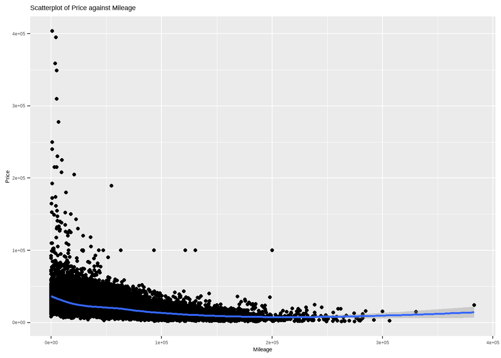

```r
# Price against mileage.

ggplot(used_car_reduced, aes(x=Mileage, y=Price)) +
  geom_point() +
  geom_smooth() +
  labs(x = "Mileage", y = "Price",
       title = "Scatterplot of Price against Mileage")
```

*Overall.*  
.Exploratory data analysis for numerical variables, specifically from correlation matrix and scatter plots suggest that the price of a used car is influenced by both its age and mileage, with newer cars and those with lower mileage tending to command higher prices.

## 7.5 Exploring categorical variables

### 7.5.1 Cities with the Highest/Lowest Number of Used Cars for Sale in the United States

```r
# Use group_by and summarize to count the number of occurrences for each city
city_counts <- used_car_reduced %>% group_by(City) %>% summarize(count = n())

# Sort the cities by count in descending order
arranged_cities <- city_counts %>% arrange(desc(count))

# Print the top 50 cities
print(arranged_cities%>%top_n(10))
```

```
## # A tibble: 10 × 2
##    City            count
##    <fct>           <int>
##  1 houston           341
##  2 sanantonio        259
##  3 louisville        187
##  4 jacksonville      186
##  5 raleigh           181
##  6 miami             177
##  7 austin            176
##  8 coloradosprings   161
##  9 orlando           159
## 10 philadelphia      137
```

```r
#Print Least 10 cities
print(arranged_cities%>%top_n(-10))
```

```
## # A tibble: 307 × 2
##    City          count
##    <fct>         <int>
##  1 acworth           1
##  2 adrian            1
##  3 alachua           1
##  4 albemarle         1
##  5 albertlea         1
##  6 albion            1
##  7 albuqueque        1
##  8 alexandercity     1
##  9 algonquin         1
## 10 amelia            1
## # ℹ 297 more rows
```

### 7.5.2 State

```r
sort(table(used_car_reduced$State))
```

```
##
##   dc   wy   vt   nd   sd   wv   mt   ri   ak   de   me   hi   ne   id   ia   nm
##    0   13   27   34   39   45   57   60   64   64   70   91  129  132  134  153
##   nh   ms   nv   ks   ar   la   sc   ok   or   mi   mn   ut   ct   wi   al   ky
##  169  207  207  222  223  262  286  292  298  310  312  318  329  334  372  421
##   mo   in   ma   md   tn   az   wa   co   oh   nj   pa   ny   va   il   ga   nc
##  473  492  530  543  571  683  715  724  730  802  834  836 1011 1120 1123 1144
##   fl   ca   tx
## 2277 2387 2893
```

From the output,  
.The state with the least number of used cars for sale is Washington, DC, followed by Wyoming and Vermont.  
.On the other hand, Texas has the highest number of used cars for sale, followed by California and Florida.

### 7.5.3 Manufacturer (Make)

```r
sort(table(used_car_reduced$Make))
```

```
##
##           am freightliner          geo        lotus      maybach      mclaren
##            0            0            0            0            0            0
##       fisker     plymouth         alfa        isuzu   rollsroyce      genesis
##            1            1            2            2            3            4
##  lamborghini   oldsmobile        aston       suzuki      bentley        tesla
##            4            4            5            6            7            8
##         saab      ferrari       saturn        smart     maserati       hummer
##            9           14           26           26           27           29
##      mercury         fiat      pontiac       jaguar        scion      porsche
##           41           52           55           77           82          120
##         mini         land   mitsubishi        volvo      lincoln        acura
##          128          131          133          138          173          324
##        buick     infiniti         audi        mazda     cadillac     chrysler
##          361          373          401          401          427          484
##       subaru        lexus          ram   volkswagen mercedesbenz          gmc
##          491          615          620          725          760          826
##          kia          bmw        dodge      hyundai         jeep        honda
##          836          989         1087         1107         1196         1453
##       nissan       toyota    chevrolet         ford
##         1998         2347         3080         3353
```

From the output,  
.The most common manufacturer of cars in the dataset are Ford, Chevrolet, Toyota, Nissan, and Honda.  
.The least common manufacturer include Isuzu, McLaren, Plymouth, Rolls-Royce, Lotus, and Lamborghini.

### 7.5.4 Model

```r
# Use group_by and summarize to count the number of occurrences for each model
model_counts <- used_car_reduced %>% group_by(Model) %>% summarize(count = n())

# Sort the models by count in descending order
arranged_models <- model_counts %>% arrange(desc(count))

# Print the top 10 models
print(arranged_models%>%top_n(10))
```

```
## # A tibble: 10 × 2
##    Model     count
##    <fct>     <int>
##  1 silverado   743
##  2 grand       561
##  3 f-1504wd    401
##  4 accord      399
##  5 3           362
##  6 civic       353
##  7 sierra      324
##  8 altima2.5   319
##  9 super       243
## 10 wrangler    237
```

```r
#Print Least 10 models
print(arranged_models%>%top_n(-10))
```

```
## # A tibble: 381 × 2
##    Model          count
##    <fct>          <int>
##  1 1500limited        1
##  2 1500r/t            1
##  3 200convertible     1
##  4 200touring         1
##  5 25002wd            1
##  6 2500big            1
##  7 2500power          1
##  8 300luxury          1
##  9 300motown          1
## 10 300uptown          1
## # ℹ 371 more rows
```

### 7.5.5 Graphical representations of categorical variables

Due to the large number of categories in our categorical variables (the minimum is 51), it is difficult to draw a bar graph for them; the bar graph becomes cluttered and difficult to read. We use a variety of strategies to make the bar graph easier to understand, such as a bar graph with the top 20 categories and a bar graph with the bottom 20 categories, both sorted by frequency count.

#### 7.5.5.1 For City

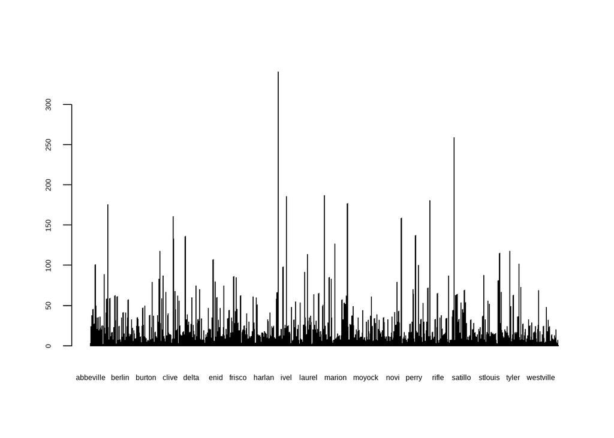

```r
#plot of all cities
city_table <- table(used_car_reduced$City)
barplot(city_table)
```

```r
# Print the top 10 cities
top_cities <- arranged_cities%>%top_n(10)
```

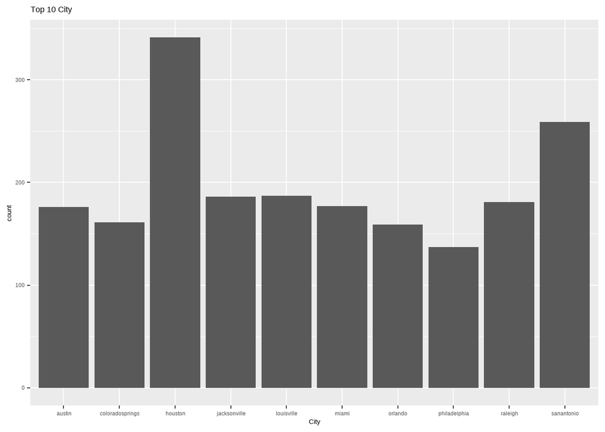

```r
#Plot the top 10 cities
ggplot(top_cities, aes(x=City, y= count)) + geom_bar(stat = "identity") + ggtitle("Top 10 City")
```

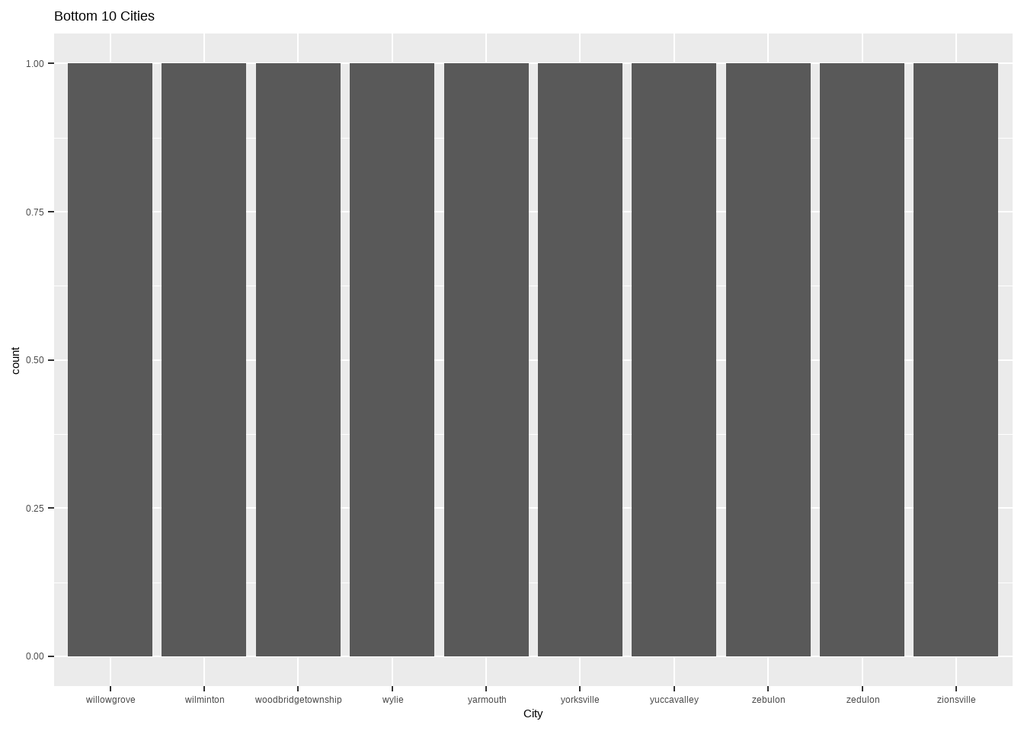

```r
#Print Least 10 cities
least_cities <- slice_tail(arranged_cities, n=10)

#Plot the least 10 cities
ggplot(least_cities, aes(x=City, y= count)) + geom_bar(stat = "identity") + ggtitle("Bottom 10 Cities")
```

*plot of all cities* .The frequency of each city in the US is displayed in a bar graph. However, the graph was challenging to interpret because the variable contained so many categories.

#### 7.5.5.2 For State

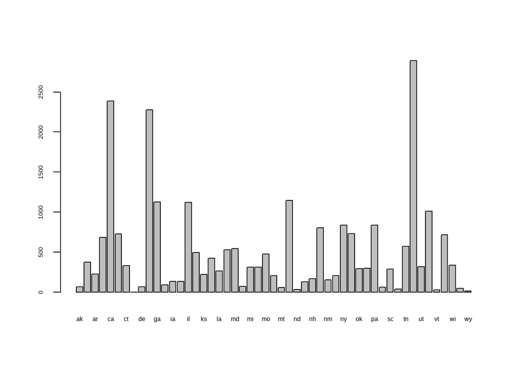

```r
#Making a State table
state_table <-table(used_car_reduced$State)

#ploting bar graph with all States
barplot(state_table)
```

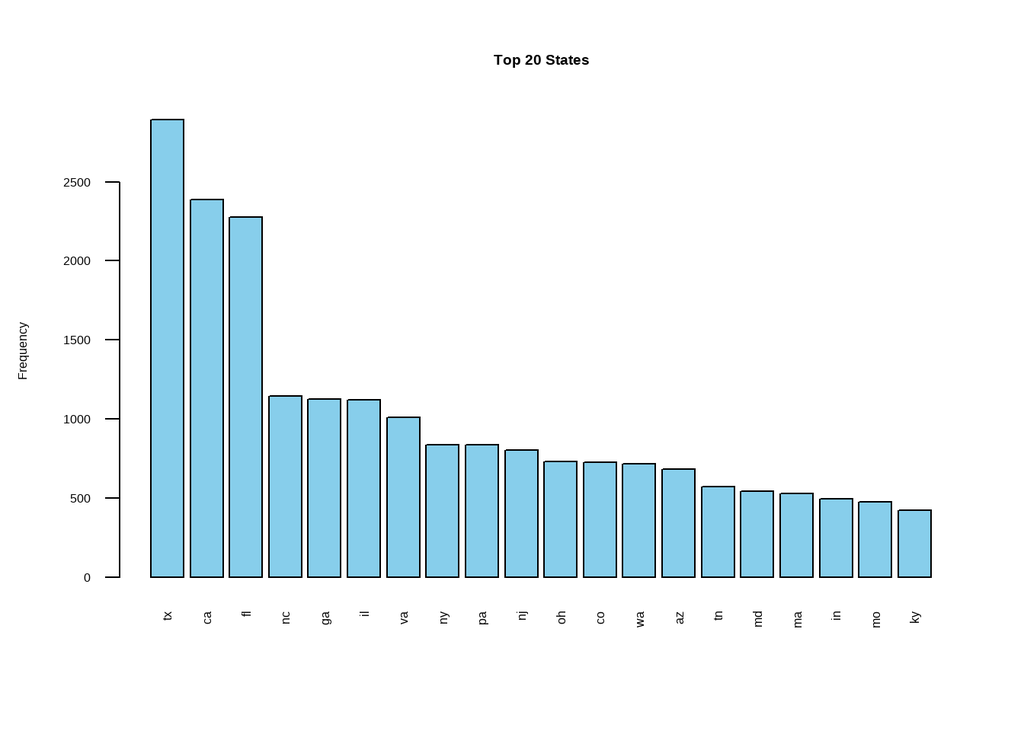

```r
#Sorting states
sorted_states <- names(sort(state_table, decreasing = TRUE))

#Top 20 States
barplot(state_table[sorted_states[1:20]], las = 2, col = "skyblue", main = "Top 20 States", ylab = "Frequency")
```

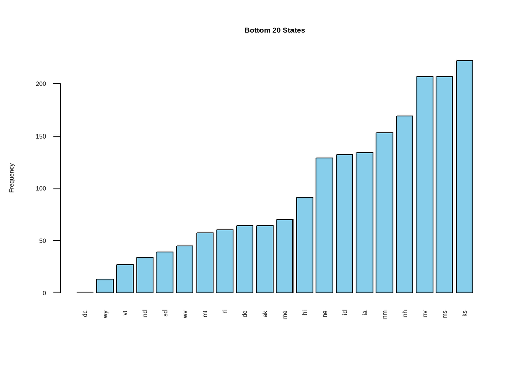

```r
#Bottom 20 States
barplot(state_table[rev(sorted_states)[1:20]], las = 2, col = "skyblue",
        main = "Bottom 20 States", ylab = "Frequency")
```

.The graphs supports the findings from the table analysis that the three states with the greatest number of used cars for sale are Texas, California, and Florida, while Washington, DC has the fewest.